# Global SuperStore

Jean Maia

2017-10-27

## Objetivos

`Global Superstore` é um dataset com informações sobre vendas da nossa store. Possui várias informações como: Lucro, Venda, quantidade e etc. Nosso Grande objetivo é explorar dados da filial Brasil com o objetivo de perceber cenários promissores, e aumentos dos lucros.

### Informações Gerais.

Os dez paises com o maior número de vendas feitas:

| Country | Vendas |
| --- | --- |
| United States | 9994 |
| Australia | 2837 |
| France | 2827 |
| Mexico | 2644 |
| Germany | 2065 |
| China | 1880 |
| United Kingdom | 1633 |
| Brazil | 1599 |
| India | 1555 |
| Indonesia | 1390 |

`Estamos entre as 10 filiais com o maior número de vendas`

Os dez paises com o maior lucro acumulado:

| Country | Lucro |
| --- | --- |
| United States | 123454719 |
| France | 34440329 |
| Australia | 33464241 |
| Mexico | 31432512 |
| Germany | 25305841 |
| China | 22118948 |
| United Kingdom | 19784868 |
| Brazil | 19280673 |
| India | 18539557 |
| Turkey | 17249715 |

`Estamos entre as 10 filiais mais geradoras de lucros.`

Os dez paises com o maior número de ítens vendidos:

| Country | Item |
| --- | --- |
| United States | 37873 |
| France | 10804 |
| Australia | 10673 |
| Mexico | 10011 |
| Germany | 7745 |
| China | 7081 |
| United Kingdom | 6161 |
| Brazil | 6148 |
| India | 5758 |
| Indonesia | 5237 |

#### A partir deste momento, o estudo irá seguir com os dados das 10 filiais mais importantes sob aspectos de números vendas, itens vendidos e maior lucratividade.

### Com o objetivo de aumentar a lucratividade, vamos trabalhar com duas principais metas:

#### 1) Aumentar o lucro por venda

#### 2) Aumentar o número de vendas.

`Se conseguirmos alcançar as duas metas, poderemos aumentar exponencialmente as nossos resultados!`

#### O gráfico abaixo justifica a definição das duas metas

[interactive chart not shown]

`EUA, que é a filial mais lucrativa, possui o maior lucro acumulado nas vendas e o maior numero de vendas.`

#### Qual filial possui maior lucro por venda?

| Country | Profit | Sales | LucroPerSale |
| --- | --- | --- | --- |
| United States | 123454719 | 113618882 | 1.086569 |
| France | 34440329 | 32463954 | 1.060879 |
| Germany | 25305841 | 24069361 | 1.051371 |
| United Kingdom | 19784868 | 19226308 | 1.029052 |
| Brazil | 19280673 | 18820957 | 1.024426 |
| Mexico | 31432512 | 30689231 | 1.024220 |
| Australia | 33464241 | 32685102 | 1.023838 |
| India | 18539557 | 18159697 | 1.020918 |
| China | 22118948 | 21911646 | 1.009461 |
| Indonesia | 16334692 | 16270765 | 1.003929 |

`Estados Unidos possuem o maior lucro por venda.`

##### Podemos observar uma grande vantagem da filial dos Estados Unidos para as outras regiões.

E parece existir uma forte relação entre lucro e vendas. Podemos afirma que esta relação é completamente linear? Vamos provar…

```
## [1] -0.149964
```

A resposta é não, pois a correlação entre os valores é baixa. Portanto, precisamos verificar de fato, quais outros principais fatores que aumentam a lucratividade completa da filial.

### Quais são os fatores mais relacionados?

`Para isto, criei um modelo preditivo, utilizando o algoritmo Random Forest. O Algoritmo irá retornar as variáveis mais similares.`

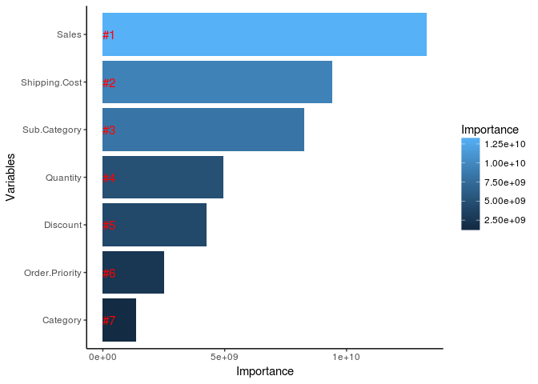

As variáveis mais relacionadas com Profit são: Sales, Frete e Sub-Category.

## Sales

Como aumentar as vendas?

Abaixo, estados Brasileiros com o maior número de vendas acumuladas.

| State | Sales | NumeroVendas | Profit |
| --- | --- | --- | --- |
| São Paulo | 4903099 | 409 | 4790412 |
| Minas Gerais | 1631502 | 135 | 1588840 |
| Bahia | 1601585 | 133 | 1675197 |
| Santa Catarina | 1144657 | 105 | 1266295 |
| Pernambuco | 986383 | 87 | 990244 |
| Rio Grande do Sul | 1021379 | 87 | 1023263 |
| Rio de Janeiro | 985609 | 78 | 1002446 |
| Parana | 775972 | 68 | 849241 |
| Maranhão | 715624 | 64 | 786827 |
| Ceará | 766207 | 63 | 780083 |

O Estado com o maior número de vendas é São Paulo, com número muito superior ao segundo colocado, Minas Gerais e o terceiro Bahia.

Seria possível explorar mercados próximos a São Paulo como Rio de Janeiro, Parana, Espiríto Santo, que possuem mercados consumidores promissores! Poderíamos revisar complemente nosso fluxo logístico para propagar o grande resultado de São Paulo para mercados mais próximos.

## Sub-Category

Brasil

| Sub.Category | Sales | count | Profit |
| --- | --- | --- | --- |
| Chairs | 1678798 | 140 | 1912165 |
| Binders | 1580738 | 134 | 1497819 |
| Copiers | 1337752 | 111 | 1357328 |
| Storage | 1265205 | 111 | 1197410 |
| Envelopes | 1342583 | 110 | 1304203 |
| Bookcases | 1185688 | 107 | 1386488 |
| Fasteners | 1143696 | 106 | 1284201 |
| Phones | 1187003 | 101 | 1295341 |
| Paper | 1222658 | 97 | 1186209 |
| Labels | 1131287 | 93 | 1170522 |

EUA e França - Paises mais lucrativos

| Sub.Category | Sales | count | Profit |
| --- | --- | --- | --- |
| Binders | 21563735 | 1920 | 24234915 |
| Paper | 15206048 | 1489 | 20104884 |
| Art | 13834897 | 1194 | 12848792 |
| Storage | 14333576 | 1186 | 14380075 |
| Furnishings | 12044696 | 1066 | 13174804 |
| Phones | 11897944 | 1044 | 12817363 |
| Accessories | 10293736 | 904 | 11259992 |
| Chairs | 8948117 | 769 | 9608966 |
| Appliances | 6596242 | 565 | 7022812 |
| Labels | 5761516 | 503 | 6388902 |

## Frete

Brasil

[interactive chart not shown]

EUA e França - Paises mais lucrativos

[interactive chart not shown]

## Os Países mais lucrativos gastam muito menos com transporte. Precisamos, junto a equipe de logística da filial Brasileira, planejar estratégias para reduzir o custo do transporte.

## Conclusão

#### 1. Logística. Inicialmente, precisamos aproveitar melhor a distribuição das nossas vendas pelo espaço geográfico Brasileiro, aproveitado mercado consumidores proximos a São Paulo. Desenvolver estratégias para reduzir custo das cargas com produtos.

Os dois tópicos devem gerar aumento nas vendas, aumento de lucro e aumento de escalabilidade da marca no Brasil.